# Principles of Ethical Digital Research

MACS 30000: Perspectives on Computational Analysis  
University of Chicago

# Ethics in Digital Research

## Why consider ethics?

- Science can have severe physical, mental, and or emotional repercussions on human subjects
  - Historical example: Tuskegee Syphilis Study
  - Subsequent government regulations and human subject research guidelines:
    - Belmont Report (1978)
    - Menlo Report (2010)
- Major concerns in a digital age
  - Informed consent
  - Unanticipated consequences of data collection
  - Algorithmic bias
  - Data privacy
- Not always clear-cut in the digital age, though…

## Four Principles of Ethical Research

- Belmont Report (1978)
  - Respect for Persons
  - Beneficence
  - Justice
- Menlo Report (2010)
  - Respect for Law and Public Interest

## Respect for persons

1. Individuals should be treated as autonomous
2. Individuals with diminished autonomy should be entitled to additional protections

## Beneficence

- Obligation researchers have to participants
  - Do not harm
  - Maximize possible benefits and minimize possible harms
- What happens if they are in conflict?
  - Need to balance these concerns
  - Conduct a risk/benefit analysis
  - Make a decision whether the benefits balance the risk;
  - Discussion: success-breeds-success study (van de Rijt et al. 2012)

## Justice

- Distribute the burdens and benefits of research
  - Is it reasonable to assign or not assign treatment to one random subset of participants?
- Initially meant protecting vulnerable people from researchers
  - Example: Studying prisoners due to convenience sampling
  - Example: Kosinski et al. (2013)’s study of predicting personal traits using public data from Facebook

## Justice

- Also emphasizes that minority groups should be proactively sought to include in study
  - Example: Facebook vote mobilization study (Bont et al. 2012)

## Respect for law and public interest

- Make sure you don’t break the law when conducting research
- Compliance
  - Terms of Service
  - Web scraping
    - *HiQ labs v. LinkedIn*
  - Aaron Swartz
- When is non-compliance ethical?
- Transparency

# Common ethical considerations in digital research

## Informed consent

- Participants should be presented with relevant information in a comprehensible format and then should voluntarily agree to participate
- Research designs where informed consent might be problematic?
  - Studies which rely on deception
    - Example: the Airbnb study you read for Assignment 1
  - Studying secondary data
- Informed consent is not always necessary, but as risks to subjects increase stronger forms of consent will be needed

## Informational risk

- Data leakage and anonymization
- Massachusetts health data

## Informational risk: Massachusetts health data

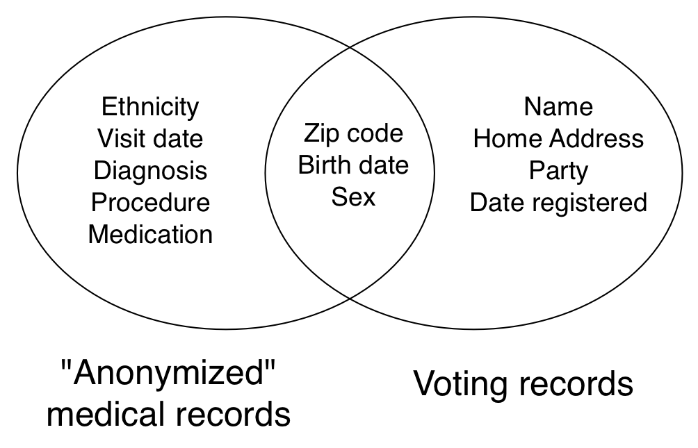

## Informational risk

- Need to balance concerns and develop data protection plans
- Differential privacy

## Privacy

> Privacy should be respected because people should be respected.

## But what is “public” vs. “private” in the digital world?

> If information is publicly accessible, then it can be used by researchers without concerns about violating people’s privacy.
- Can it?

# Institutional Review Board (IRB)

## Who needs to submit to IRB review

> **Research** projects involving **human subjects** require review and approval by an Institutional Review Board.

## Research

> A systematic investigation, including research development, testing and evaluation, designed to develop or contribute to generalizable knowledge

## Human subject

> A living individual **about whom** an investigator (whether professional or student) conducting research obtains (1) data through **intervention** or **interaction** with the individual, or (2) identifiable **private information**.

## About whom

> To be considered research with “human subjects,” the data received from a living individual must be about the person.

## Intervention

> Includes both physical procedures by which data are gathered and manipulations of the subject or the subject’s environment that are performed for research purposes.

## Interaction

> Includes communication or interpersonal contact between investigator and subject.

## Private information

> Includes information about behavior that occurs in a context in which an individual can reasonably expect that no observation or recording is taking place, and information which has been provided for specific purposes by an individual and which the individual can reasonably expect will not be made public

## When are studies not research with human subjects?

- Data collection for internal purposes
- Internal class projects not designed to be generalizable or used beyond the class
- Some examples that do not meet the definition of *human subjects* (according to the SBS IRB):
  - Data available to the general public
  - Analysis of data/specimens from deceased individuals
  - Observations in a public park
  - Thoughts?

The IRB is a floor, not a ceiling!

## General IRB Considerations

- Minimal risk
  - “[T]he probability and magnitude of harm or discomfort anticipated in the research are not greater in and of themselves than those ordinarily encountered in daily life or during the performance of routine physical or psychological examinations or tests.”
  - Are research subjects part of a vulnerable population?
  - Types of potential risks: physical, psychological, social, economic, legal, etc.
- Informed consent
- Data confidentiality and provisions to protect privacy of research subjects

## Human subjects protection training

- Complete [human subjects protection training](https://sbsirb.uchicago.edu/training/)
  - “Social and Behavioral Sciences IRB Human Subjects Protection Training Course”
  - Most Important Elective Modules for CSS:
    - “Human Subjects Considerations and Big Data Research”
    - “Internet-Based Research”
- Must be done before submitting an IRB proposal (and required for this class as a part of your final proposal grade!)

**If in doubt about whether your project requires IRB approval, ask!**

- In MACSS: Sabrina Biggus (Student Affairs Administrator) is our IRB liason who will guide your project through the IRB process

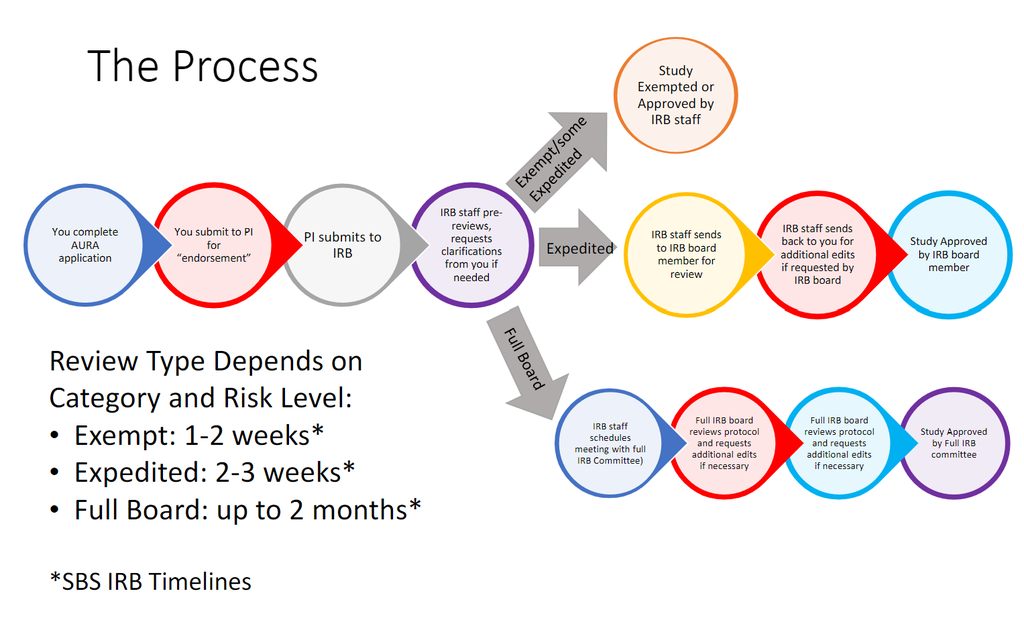

Source: “Navigating the IRB Process” slides from SBS IRB

## Next class: Evaluating the Ethics of Digital Research

1. Read Kramer et al. (2014)’s Facebook contagion study and Watts (2014)’s defense and answer: should this research be allowed?
2. Discuss the ethics of the collection/release of the “Tastes, Ties, and Time” dataset (Zimmer 2010) in light of the 4 principles of ethical research.
3. Mental Exercise: Debate the ethics of Milkman et al.(2012)’s research design
   - Before class: read the Canvas prompt and think about the questions
   - In class: Will randomly split class into two groups (so think about both positions as you read!)
     - Group 1: “Balanced across the 4 principles of ethical research, this is an ethical study”
     - Group 2: “Balanced across the 4 principles of ethical research, this is an unethical study”